# General Social Survey

Yuripsa Palacios Sosa

October 14, 2019

# 1 Introduction Question 1

This data is from the 2018 General Social Survey. The first blocks of R-code has selected down a subset of the data to just 15 variables. It has further removed unwanted factor levels in much of the data. Examine that code to see what it is doing. Finally address this question. Is opinion on the death penalty (CAPPUN) independent of gun ownership (OWNGUN)?

## 1.1 Methods

Both of the variables are both categorical: hence we will use a bar chart to graphically show the data, and a cross-tabulation for a numerical summary. A Chi-squared test will be use to infer whether or not there is a relationship between the variables

$H_o$There is no relationship between opinion on the death penalty and gun ownership.

$H_A$There is a relationship between opinion on the death penalty and gun ownership.

## 1.2 Results

### 1.2.1 Descriptive Results

#### 1.2.1.1 Graphical Descriptive Results

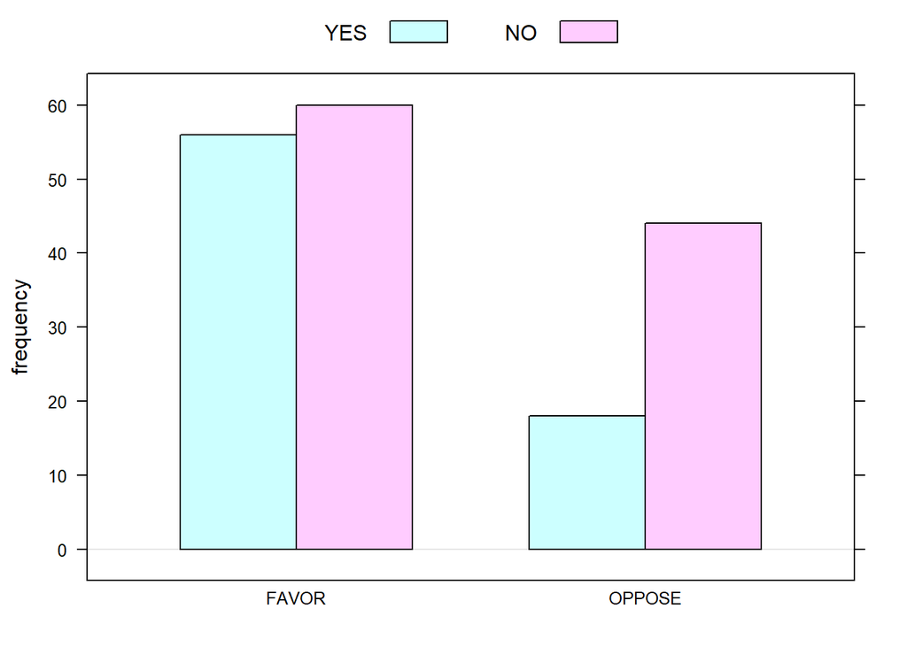

```r
barchartGC(~CAPPUN+OWNGUN, data = mydata4)
```

This bar chart shows that there is a connection between gun ownership and whether one is in favor of capital punishment. Based off of the chart people who said they owned a gun were also in favor of capital punishment

#### 1.2.1.2 Numerical Descriptive Results

```r
tab1 = xtabs(~CAPPUN+OWNGUN, data = mydata4)
rowPerc(tab1)
```

```
##         OWNGUN
## CAPPUN      YES     NO  Total
##   FAVOR   48.28  51.72 100.00
##   OPPOSE  29.03  70.97 100.00
```

This table shows that there is a connection between gun ownership and whether one is in favor of capital punishment. it appears people who said yes they own a gun were more in favor of capital punishment. People whoe said no to owning a gun were more likely to oppose capital punishment

### 1.2.2 Inferential Results

```r
chisqtestGC(tab1)
```

```
## Pearson's Chi-squared test with Yates' continuity correction
##
## Observed Counts:
##         OWNGUN
## CAPPUN   YES NO
##   FAVOR   56 60
##   OPPOSE  18 44
##
## Counts Expected by Null:
##         OWNGUN
## CAPPUN     YES    NO
##   FAVOR  48.22 67.78
##   OPPOSE 25.78 36.22
##
## Contributions to the chi-square statistic:
##         OWNGUN
## CAPPUN    YES   NO
##   FAVOR  1.25 0.89
##   OPPOSE 2.35 1.67
##
##
## Chi-Square Statistic = 5.3932
## Degrees of Freedom of the table = 1
## P-Value = 0.0202
```

The p-value for the Chisq test is 0.02 this is less than 0.05 so we reject the null hypothesis and conclude we have the evidence to support the assertion that gun ownership and whether one favors capital punishment are related. It appears people who do not own guns tend to not favor capital punishment, white people who own guns tend to favor capital punishment.

# 2 Introduction Question 2

Is belief in the bigbang theory (BIGBANG) independent of belief in the afterlife (POSTLIFE)

## 2.1 Methods

Both variables in this analysis are categorical; hence we use bar graphs and tables to summarize the data and a chi-squared test for inference.

$H_o$Belief in the big bang theory is independent of belief in the afterlife.

$H_A$Belief in the big bang theory is dependent of belief in the afterlife

## 2.2 Results

### 2.2.1 Descriptive Results

#### 2.2.1.1 Graphical Descriptive Results

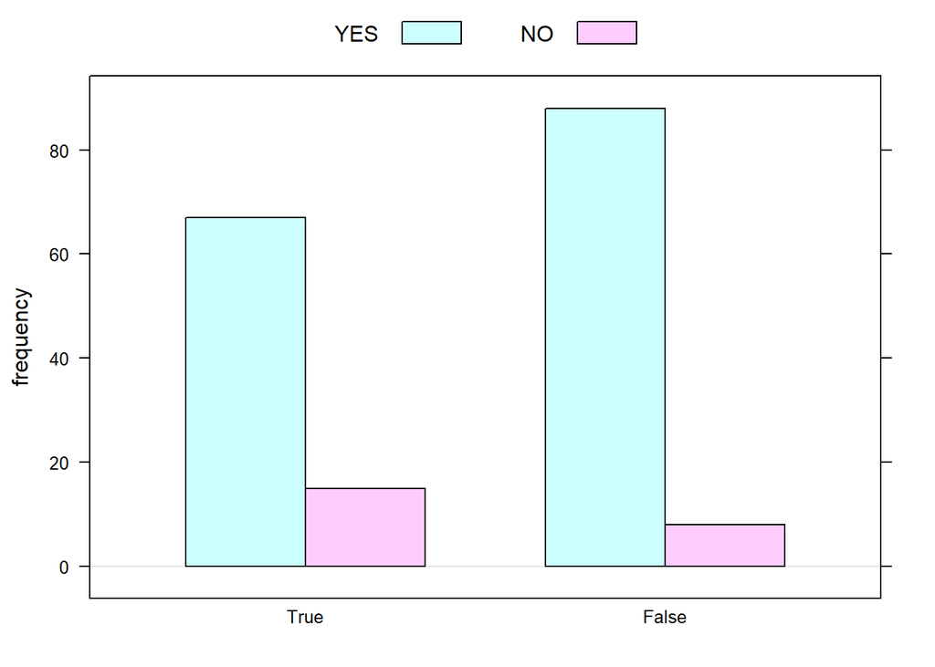

```r
barchartGC(~BIGBANG+POSTLIFE, data = mydata4)
```

The bar chart suggests there is no connection between those who believe in the big bang theory and those who believe in the afterlife. People who said yes to believing in the big bang theory also said yes to believing in the after life, but similar numbers of people who said they didn’t believe in the big bang theory also said they did believe in the after life. This leaves us to belive that more people believe in the after life then they do the big bang theory

#### 2.2.1.2 Numerical Descriptive Results

```r
tab1 = xtabs(~BIGBANG+POSTLIFE, data = mydata4)
rowPerc(tab1)
```

```
##        POSTLIFE
## BIGBANG    YES     NO  Total
##   True   81.71  18.29 100.00
##   False  91.67   8.33 100.00
```

The table suggests there is no connection between those who believe in the big bang theory and those who believe in the afterlife. The people who believe in the after life have have a high similar number of people who believe and who dont believe in the big bang theory. This leaves us to believe that the belief in the afterlife has no connection to belief in or therefore the lack of belief in the big bang theory

### 2.2.2 Inferential Results

```r
chisqtestGC(tab1)
```

```
## Pearson's Chi-squared test with Yates' continuity correction
##
## Observed Counts:
##        POSTLIFE
## BIGBANG YES NO
##   True   67 15
##   False  88  8
##
## Counts Expected by Null:
##        POSTLIFE
## BIGBANG  YES   NO
##   True  71.4 10.6
##   False 83.6 12.4
##
## Contributions to the chi-square statistic:
##        POSTLIFE
## BIGBANG  YES   NO
##   True  0.27 1.83
##   False 0.23 1.56
##
##
## Chi-Square Statistic = 3.0637
## Degrees of Freedom of the table = 1
## P-Value = 0.0801
```

# 3 Introduction Question 3

Finally determine if a persons opinion on death penalty (CAPPUN) is independent of their race (RACE).

## 3.1 Methods

Both variables in this analysis are categorical; hence we use bar graphs and tables to summarize the data and a chi-squared test for inference

$H_o$ a persons opinion on the death penalty is independent of their race.

$H_A$ a persons opinion on death penalty is dependent of their race.

## 3.2 Results

### 3.2.1 Descriptive Results

#### 3.2.1.1 Graphical Descriptive Results

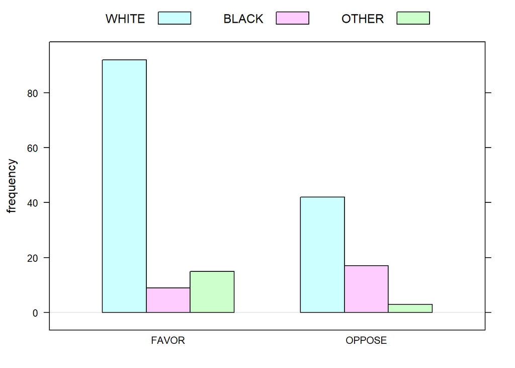

```r
barchartGC(~CAPPUN+RACE, data = mydata4)
```

The bar chart suggests there is a connection between those who believe in capital punishment and their race. A persons opinion on capital punishment appears to be dependent of their race. White people tend to favor capital punishment more then blacks who are more likely to oppose capital punishment. White tend to be more opinionated according to the high number of votes to favor or oppose capital punishment.

#### 3.2.1.2 Numerical Descriptive Results

```r
tab1 = xtabs(~CAPPUN+RACE, data = mydata4)
rowPerc(tab1)
```

```
##         RACE
## CAPPUN    WHITE  BLACK  OTHER  Total
##   FAVOR   79.31   7.76  12.93 100.00
##   OPPOSE  67.74  27.42   4.84 100.00
```

### 3.2.2 Inferential Results

```r
chisqtestGC(tab1)
```

```
## Pearson's Chi-squared test
##
## Observed Counts:
##         RACE
## CAPPUN   WHITE BLACK OTHER
##   FAVOR     92     9    15
##   OPPOSE    42    17     3
##
## Counts Expected by Null:
##         RACE
## CAPPUN   WHITE BLACK OTHER
##   FAVOR  87.33 16.94 11.73
##   OPPOSE 46.67  9.06  6.27
##
## Contributions to the chi-square statistic:
##         RACE
## CAPPUN   WHITE BLACK OTHER
##   FAVOR   0.25  3.72  0.91
##   OPPOSE  0.47  6.97  1.71
##
##
## Chi-Square Statistic = 14.0272
## Degrees of Freedom of the table = 2
## P-Value = 9e-04
```

# 4 Discussion and Conclusion

Question #1, the p-value for the Chisq test is 0.02 this is less than 0.05 so we reject the null hypothesis and conclude we have the evidence to support the assertion that gun ownership and whether one favors capital punishment are related. It appears people who do not own guns tend to not favor capital punishment, while people who own guns tend to favor capital punishment.